# Sale Price Predictions

Amy Fedewa

April 24, 2019

```r
knitr::opts_chunk$set(echo = TRUE)
```

```r
library(dplyr)
```

```r
library(ggplot2)
library(MLmetrics)
library(readr)
library(tidyr)
library(corrplot)
```

## Introduction

For this project I really wanted to focus on using R for statistical analysis of some kind because I think I will be using it a lot n my future career as an actuary.

Originally for this project,I had entered a Kaggle competition that provides a large data set on movies and their profits earned. I would use this data to come up with the best box office prediction formulas I can using R.

I ended up switching to a different Kaggle competition. The data for the original competition would mostly be more difficult to process, because it consisted of categories like title, or ‘crew’ and other longs strings. I wasn’t really interested in processing these strings of information, and I felt it would be more difficult to showcase what I leaned in this course, so I switched to a different Kaggle competition with a more ‘friendly’ data set. This competition was to predict home prices. Note that a lot of the data cleaning portion was done in class on the very last day. I don’t want to take credit for those portions.

First, I’ll load the train and test sets into R:

```r
House_Train <- read.table("train.csv", header=TRUE, sep= ",", stringsAsFactors=FALSE)
House_Test<- read.table ("test.csv", header=TRUE, sep= ",", stringsAsFactors=FALSE)
head(House_Train)
```

```
##   Id MSSubClass MSZoning LotFrontage LotArea Street Alley LotShape
## 1  1         60       RL          65    8450   Pave  <NA>      Reg
## 2  2         20       RL          80    9600   Pave  <NA>      Reg
## 3  3         60       RL          68   11250   Pave  <NA>      IR1
## 4  4         70       RL          60    9550   Pave  <NA>      IR1
## 5  5         60       RL          84   14260   Pave  <NA>      IR1
## 6  6         50       RL          85   14115   Pave  <NA>      IR1
##   LandContour Utilities LotConfig LandSlope Neighborhood Condition1
## 1         Lvl    AllPub    Inside       Gtl      CollgCr       Norm
## 2         Lvl    AllPub       FR2       Gtl      Veenker      Feedr
## 3         Lvl    AllPub    Inside       Gtl      CollgCr       Norm
## 4         Lvl    AllPub    Corner       Gtl      Crawfor       Norm
## 5         Lvl    AllPub       FR2       Gtl      NoRidge       Norm
## 6         Lvl    AllPub    Inside       Gtl      Mitchel       Norm
##   Condition2 BldgType HouseStyle OverallQual OverallCond YearBuilt
```

[output cut: 76 more lines]

```r
head(House_Test)
```

```
##     Id MSSubClass MSZoning LotFrontage LotArea Street Alley LotShape
## 1 1461         20       RH          80   11622   Pave  <NA>      Reg
## 2 1462         20       RL          81   14267   Pave  <NA>      IR1
## 3 1463         60       RL          74   13830   Pave  <NA>      IR1
## 4 1464         60       RL          78    9978   Pave  <NA>      IR1
## 5 1465        120       RL          43    5005   Pave  <NA>      IR1
## 6 1466         60       RL          75   10000   Pave  <NA>      IR1
##   LandContour Utilities LotConfig LandSlope Neighborhood Condition1
## 1         Lvl    AllPub    Inside       Gtl        NAmes      Feedr
## 2         Lvl    AllPub    Corner       Gtl        NAmes       Norm
## 3         Lvl    AllPub    Inside       Gtl      Gilbert       Norm
## 4         Lvl    AllPub    Inside       Gtl      Gilbert       Norm
## 5         HLS    AllPub    Inside       Gtl      StoneBr       Norm
## 6         Lvl    AllPub    Corner       Gtl      Gilbert       Norm
##   Condition2 BldgType HouseStyle OverallQual OverallCond YearBuilt
```

[output cut: 76 more lines]

Note that the train data contains an extra column for sale price, which we will predict for the test set.

I will use many of R’s libraries, all of which I will load above.

## Data visulization

This data is nice because it contains a combination of types. Many are categorical, but some are years, such as year sold and year built. Things like square footage are numeric, so there’s many thing we can visualize here.

A description of each data type is included in an attached text file.

The summary function can quickly provide an overview of all data. One must be careful to remember that some of the variables like MSSubClass are categorical, so the summaries given here are meaningless. However, its easy to see stats of the truly numeric variables. For example, we see that the houses in this data set were built between 1872 and 2010 with a mean year of 1971 and median of 1973.

```r
summary(House_Train)
```

```
##        Id           MSSubClass      MSZoning          LotFrontage
##  Min.   :   1.0   Min.   : 20.0   Length:1460        Min.   : 21.00
##  1st Qu.: 365.8   1st Qu.: 20.0   Class :character   1st Qu.: 59.00
##  Median : 730.5   Median : 50.0   Mode  :character   Median : 69.00
##  Mean   : 730.5   Mean   : 56.9                      Mean   : 70.05
##  3rd Qu.:1095.2   3rd Qu.: 70.0                      3rd Qu.: 80.00
##  Max.   :1460.0   Max.   :190.0                      Max.   :313.00
##                                                      NA's   :259
##     LotArea          Street             Alley             LotShape
##  Min.   :  1300   Length:1460        Length:1460        Length:1460
##  1st Qu.:  7554   Class :character   Class :character   Class :character
##  Median :  9478   Mode  :character   Mode  :character   Mode  :character
##  Mean   : 10517
##  3rd Qu.: 11602
##  Max.   :215245
##
##  LandContour         Utilities          LotConfig
##  Length:1460        Length:1460        Length:1460
##  Class :character   Class :character   Class :character
##  Mode  :character   Mode  :character   Mode  :character
##
##
##
##
##   LandSlope         Neighborhood        Condition1
##  Length:1460        Length:1460        Length:1460
##  Class :character   Class :character   Class :character
##  Mode  :character   Mode  :character   Mode  :character
##
##
##
##
##   Condition2          BldgType          HouseStyle         OverallQual
##  Length:1460        Length:1460        Length:1460        Min.   : 1.000
##  Class :character   Class :character   Class :character   1st Qu.: 5.000
##  Mode  :character   Mode  :character   Mode  :character   Median : 6.000
##                                                           Mean   : 6.099
##                                                           3rd Qu.: 7.000
##                                                           Max.   :10.000
##
```

[output cut: 121 more lines]

```
##  Min.   :    0.00   Min.   : 1.000   Min.   :2006   Length:1460
##  1st Qu.:    0.00   1st Qu.: 5.000   1st Qu.:2007   Class :character
##  Median :    0.00   Median : 6.000   Median :2008   Mode  :character
##  Mean   :   43.49   Mean   : 6.322   Mean   :2008
##  3rd Qu.:    0.00   3rd Qu.: 8.000   3rd Qu.:2009
##  Max.   :15500.00   Max.   :12.000   Max.   :2010
##
##  SaleCondition        SalePrice
##  Length:1460        Min.   : 34900
##  Class :character   1st Qu.:129975
##  Mode  :character   Median :163000
##                     Mean   :180921
##                     3rd Qu.:214000
##                     Max.   :755000
##
```

There are many different types of plots in R. Here are just a few. looking at the square feet on the first floor:

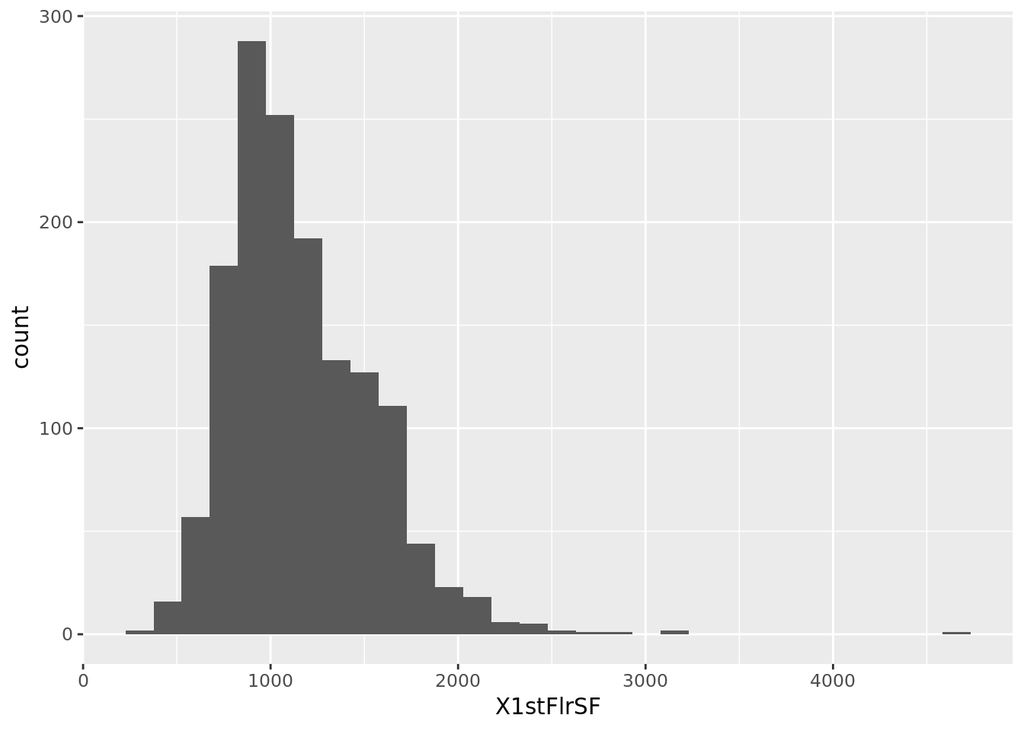

```r
ggplot(data=House_Train) + geom_histogram(mapping=aes(x=X1stFlrSF))
```

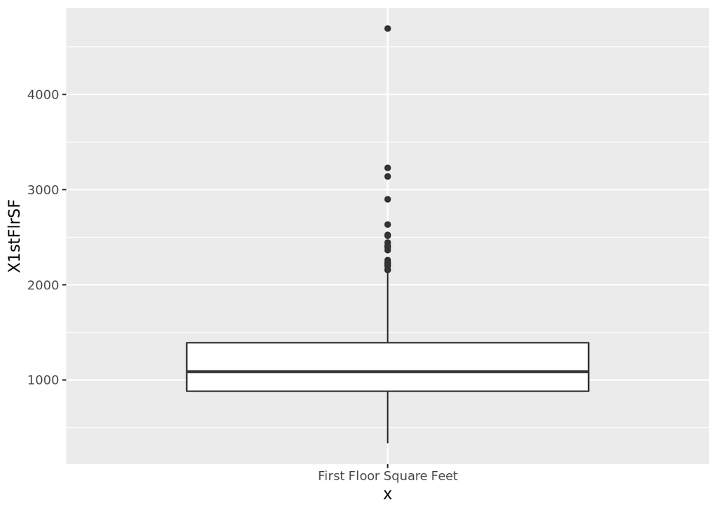

```r
ggplot(data=House_Train) + geom_boxplot(aes(x="First Floor Square Feet", y= X1stFlrSF))
```

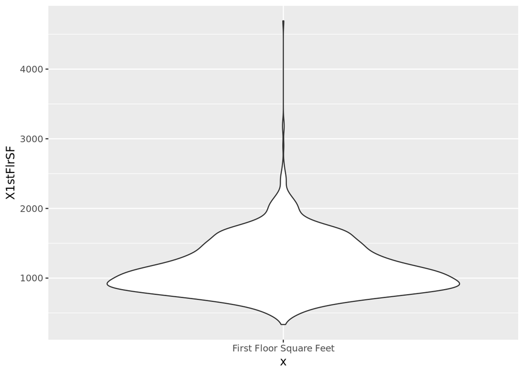

```r
ggplot(data=House_Train) + geom_violin(aes(x="First Floor Square Feet", y= X1stFlrSF))
```

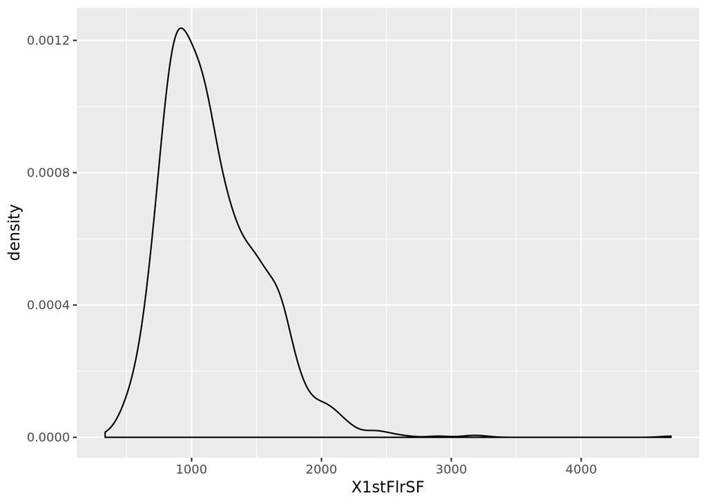

```r
ggplot(data=House_Train) + geom_density(aes(x=X1stFlrSF))
```

These 4 plots all show that the data for the first floor square feet is right skewed with several outliers. The upper points on the box plot show these outliers, while the other plots just show the shape of the distribution.

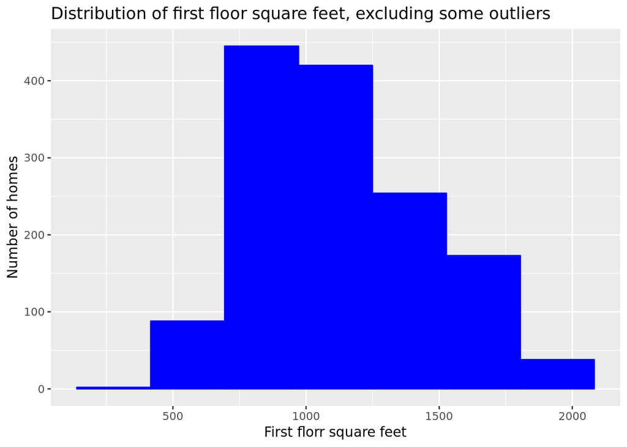

```r
FirstFloorSqrFeetLessOutliers<- subset(House_Train, X1stFlrSF<=2000)
ggplot(data=FirstFloorSqrFeetLessOutliers) + geom_histogram(bins = 7, color= "blue", fill="blue", mapping=aes(x=X1stFlrSF))+  labs(title ="Distribution of first floor square feet, excluding some outliers", x= "First florr square feet", y="Number of homes")
```

Here, I arbitrarily choose 7 bins. However, there are statistical methods to determine the best number of bins. Here I use the Freedman-Diaconis method

```r
numbins_FD <- function(data_col){ceiling((max(data_col)- min(data_col))/(2*IQR(data_col, na.rm = FALSE, type = 7))/(length(data_col))^(1/3))

}

numbins_FD(FirstFloorSqrFeetLessOutliers$X1stFlrSF)
```

```
## [1] 1
```

Oh no! this returns the value of only 1 bin. That’s not very helpful. This is happening because this data is not normally distributed and is instead skewed right. If I wanted a way to estimate the number of bins needed, I would need to look into a different method.

It’s easy to create side-by-side box plots:

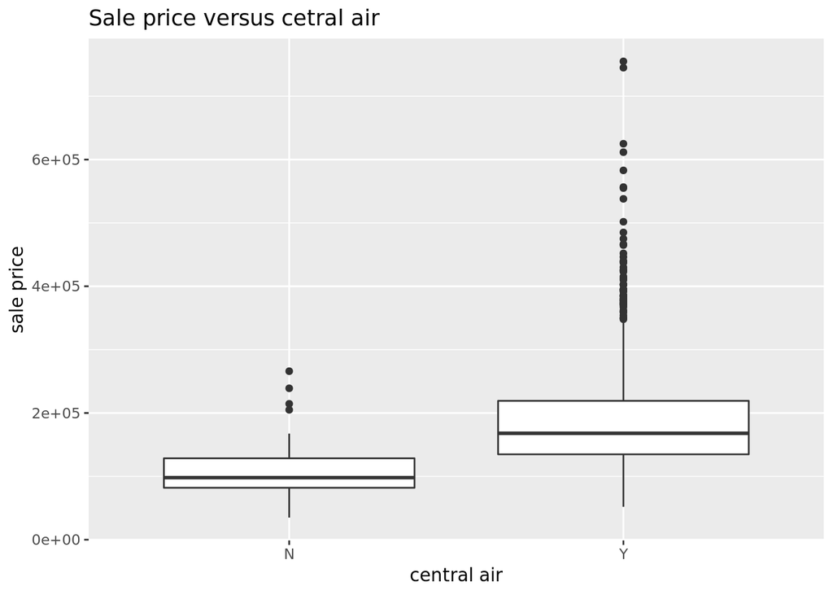

```r
ggplot(data=House_Train) + geom_boxplot(aes(x=House_Train$CentralAir, y= House_Train$SalePrice))+  labs(title ="Sale price versus cetral air", x= "central air", y="sale price")
```

Here we see that houses with central air seem to sell for significantly more than those without.

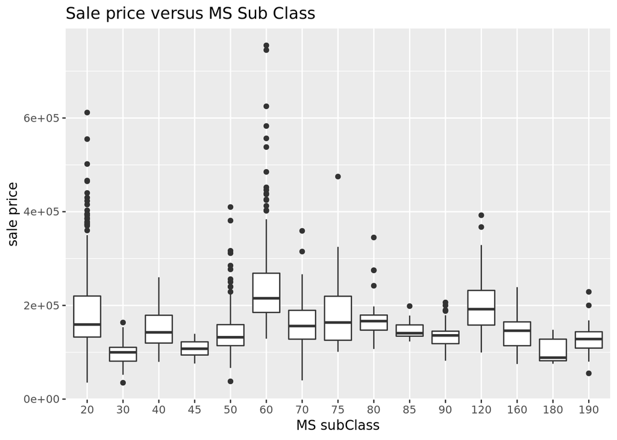

```r
House_Train$MSSubClass= as.factor(House_Train$MSSubClass)

ggplot(data=House_Train) + geom_boxplot(aes(x=House_Train$MSSubClass, y= House_Train$SalePrice))+  labs(title ="Sale price versus MS Sub Class", x= "MS subClass", y="sale price")
```

Here, I had to convert MS SubClass to a factor before proceeding. We can see the subclass of 60 (2 story and new) has a higher selling price than say, class 45 (1.5 stories and unfinished4), which makes perfect sense.

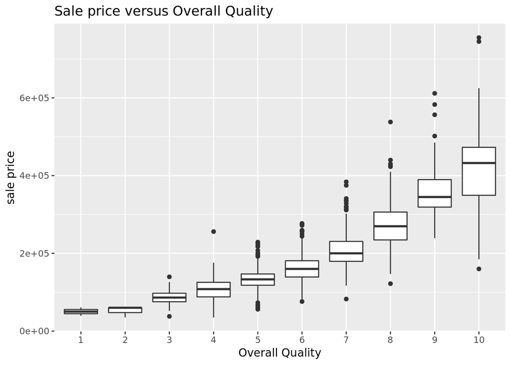

```r
House_Train$OverallQual= as.factor(House_Train$OverallQual)
House_Train$OverallCond= as.factor(House_Train$OverallCond)

ggplot(data=House_Train) + geom_boxplot(aes(x=House_Train$OverallQual, y= House_Train$SalePrice))+  labs(title ="Sale price versus Overall Quality", x= "Overall Quality", y="sale price")
```

Here we see that as overall quality of the house increases, so does sale price. Interestingly, we can also see that the variation in sale prices also increases as sales price goes up.

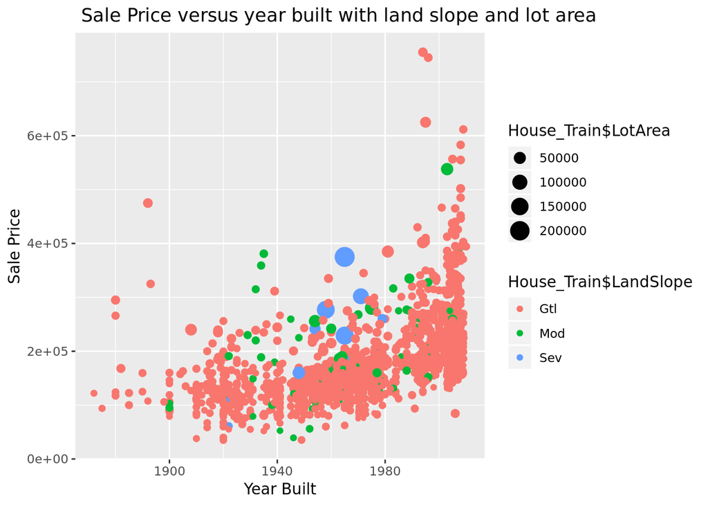

```r
ggplot(House_Train) + geom_point(aes(x=House_Train$YearBuilt, y=House_Train$SalePrice, color=House_Train$LandSlope, size= House_Train$LotArea)) + labs(title =" Sale Price versus year built with land slope and lot area", x= "Year Built", y="Sale Price")
```

There are many different ways we could visualize this data. I’ll use more if needed, but I’ll move on for now.

## dtata manipulation

Now I’ll look at ways to manipulate my data to make it easier to process. I’m going to leave my original data frame alone and do this work in a new data frame House_Train2 Am significant amount of data cleaning will need to be done here.

```r
House_Train %>%
  summarise_all(funs(sum(is.na(.)))) %>%
  gather(key = 'variable', value = 'num_na') %>%
  filter(num_na > 0) %>%
  arrange(desc(num_na))
```

```
##        variable num_na
## 1        PoolQC   1453
## 2   MiscFeature   1406
## 3         Alley   1369
## 4         Fence   1179
## 5   FireplaceQu    690
## 6   LotFrontage    259
## 7    GarageType     81
## 8   GarageYrBlt     81
## 9  GarageFinish     81
## 10   GarageQual     81
## 11   GarageCond     81
## 12 BsmtExposure     38
## 13 BsmtFinType2     38
## 14     BsmtQual     37
## 15     BsmtCond     37
## 16 BsmtFinType1     37
## 17   MasVnrType      8
## 18   MasVnrArea      8
## 19   Electrical      1
```

We need to deal with missing values first.

```r
House_Train$PoolQC <- replace_na(House_Train$PoolQC, 'no_pool')
House_Train$Alley <- replace_na(House_Train$Alley, 'no_alley')
House_Train$Fence <- replace_na(House_Train$Fence, 'no_fence')
House_Train$FireplaceQu <- replace_na(House_Train$FireplaceQu, 'no_fireplace')
House_Train <- House_Train %>%
  mutate_at(vars(starts_with('Garage')), replace_na, 'no_garage')

House_Train$GarageArea <- as.numeric(House_Train$GarageArea)

House_Train<- House_Train %>%
  mutate_at(vars(GarageArea), replace_na, 0)

House_Train <- House_Train %>%
  mutate_at(vars(starts_with('Bsmt')), replace_na, 'no_basement')
House_Train<- House_Train %>%
  mutate_at(vars(LotFrontage), replace_na, 0)
```

```r
House_Train <- House_Train %>%
  mutate_at(vars(starts_with('MiscF')), replace_na, 'no_feature')

House_Train <- House_Train %>%
  mutate_at(vars(MasVnrType), replace_na, 'None')

House_Train<- House_Train %>%
  mutate_at(vars(MasVnrArea), replace_na, 0)

House_Train<- House_Train %>%
  mutate_at(vars(Electrical), replace_na, 'None')
```

```r
House_Train <- House_Train[, 2:ncol(House_Train)]
```

```r
House_Train%>%
  summarise_all(funs(sum(is.na(.)))) %>%
  gather(key = 'variable', value = 'num_na') %>%
  filter(num_na > 0) %>%
  arrange(desc(num_na))
```

```
## [1] variable num_na
## <0 rows> (or 0-length row.names)
```

## Model assumptions

For this data I will develop a linear model. We also talked about logistic models in this course, but that would be used where the response variable is binary, which sale price is not.

To find the best model, we want the smallest least squared error as possible.  
It is important to understand this concept when developing a linear model.

When we pick a regression line, each data point will have a value predicted by the line. Often, this value is called y-hat. The distance between this predicted value and the actual data point is called an error or residual.

Residuals can be positive or negative. Therefore, we can’t simply add them together to get an idea of how much error there is overall. Therefore we square these error terms first and then add them together. This gives us the least squared error or residual squared error. Better predictive models will have smaller distances between Y and Y-hat, and therefore, smaller residual squared error.

Linear regression involves several important assumptions.

1. The errors are normally distributed This means that overall, the errors sum to zero.
2. Constant variance of the error terms This term is also referred to as heteroskedasticity. As the Y values get larger, we expect the variance of those values to stay the same. If this is not the case, a plot of y-hat versus the residual will show a distinct fan-out pattern. While heteroskedasticity does lead to wider confidence intervals for the data, it does not lead to biased estimates
3. No multicollinearity In other words, the x variables used in the model should be independent of each other

```r
rmse <- function(y, yhat) sqrt(mean((y - yhat)^2))
```

Here is another important function:

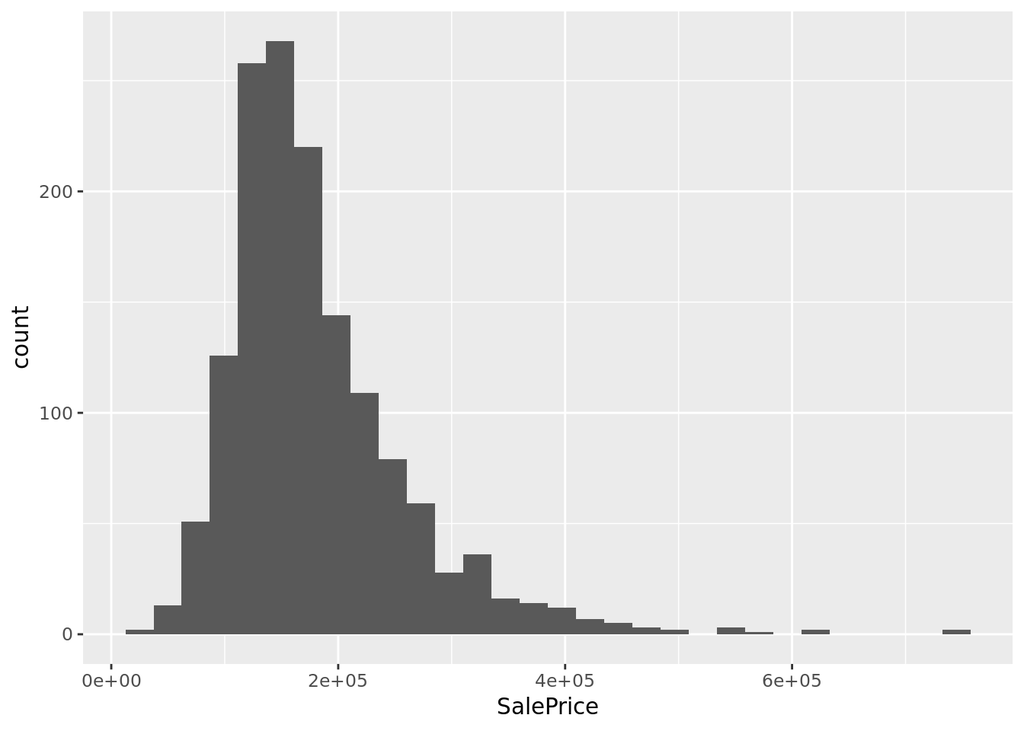

```r
Zval<-function(x) (x-mean(x))/sd(x)
ggplot(data=House_Train) + geom_histogram(mapping=aes(x=SalePrice))
```

```r
##House_Train<-House_Train %>%mutate(Zprice=Zval(SalePrice))
##House_Train%>% filter(Zprice>3) %>% select(Zprice)%>%arrange(desc(Zprice))
```

By standardizing the numerical variables, we can identify and potentially eliminate outliers. However, this data is skewed to the right. We don’t want to simply eliminate more extreme values in this case

```r
numeric_vars <- which(sapply(House_Train, is.numeric))
numeric_vars
```

```
##   LotFrontage       LotArea     YearBuilt  YearRemodAdd    MasVnrArea
##             3             4            19            20            26
##   TotalBsmtSF     X1stFlrSF     X2ndFlrSF  LowQualFinSF     GrLivArea
##            38            43            44            45            46
##      FullBath      HalfBath  BedroomAbvGr  KitchenAbvGr  TotRmsAbvGrd
##            49            50            51            52            54
##    Fireplaces    GarageArea    WoodDeckSF   OpenPorchSF EnclosedPorch
##            56            62            66            67            68
##    X3SsnPorch   ScreenPorch      PoolArea       MiscVal        MoSold
##            69            70            71            75            76
##        YrSold     SalePrice
##            77            80
```

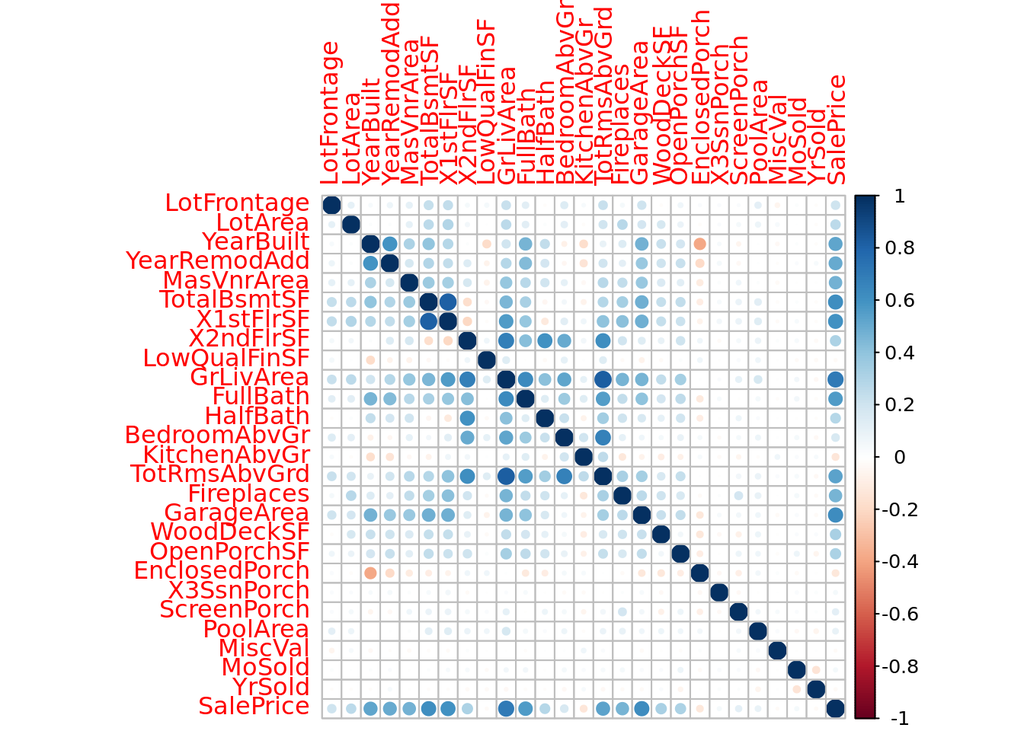

```r
corrplot(cor(House_Train[, numeric_vars], use="pairwise.complete.obs"))
```

This plot is very difficult to read. Note that as expected, we have one to one correlations down the middle since variables will obviously correlate 100% with themselves.

Variables that correlate with sale price are the ones we will want to use in the final model.

```r
cor_matrix<-cor(House_Train[, numeric_vars], use="pairwise.complete.obs")
highcor_thresh <- 0.5
cor_saleprice <- cor_matrix[, 'SalePrice']
cor_saleprice[cor_saleprice > highcor_thresh]
```

```
##    YearBuilt YearRemodAdd  TotalBsmtSF    X1stFlrSF    GrLivArea
##    0.5228973    0.5071010    0.6135806    0.6058522    0.7086245
##     FullBath TotRmsAbvGrd   GarageArea    SalePrice
##    0.5606638    0.5337232    0.6234314    1.0000000
```

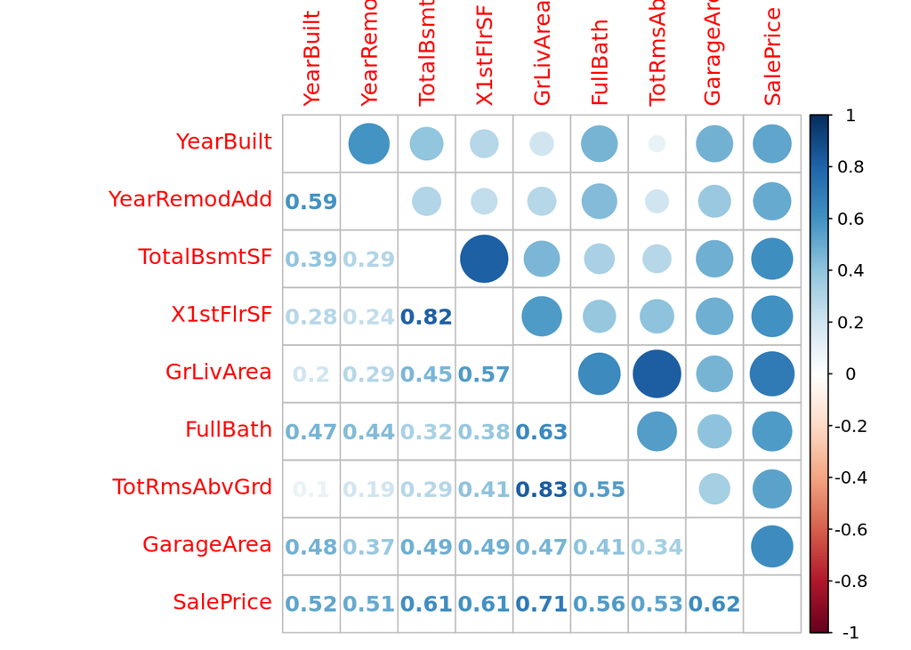

```r
highcor_vars <- names(cor_saleprice[cor_saleprice > highcor_thresh])
corrplot.mixed(cor(House_Train[, highcor_vars], use="pairwise.complete.obs"),
               tl.pos = "lt")
```

We can see which variables correlate with price here. BUT one of the assumptions of linear regression is that the x variables will be independent. If we were to use all of the variables here, this would not be the case.

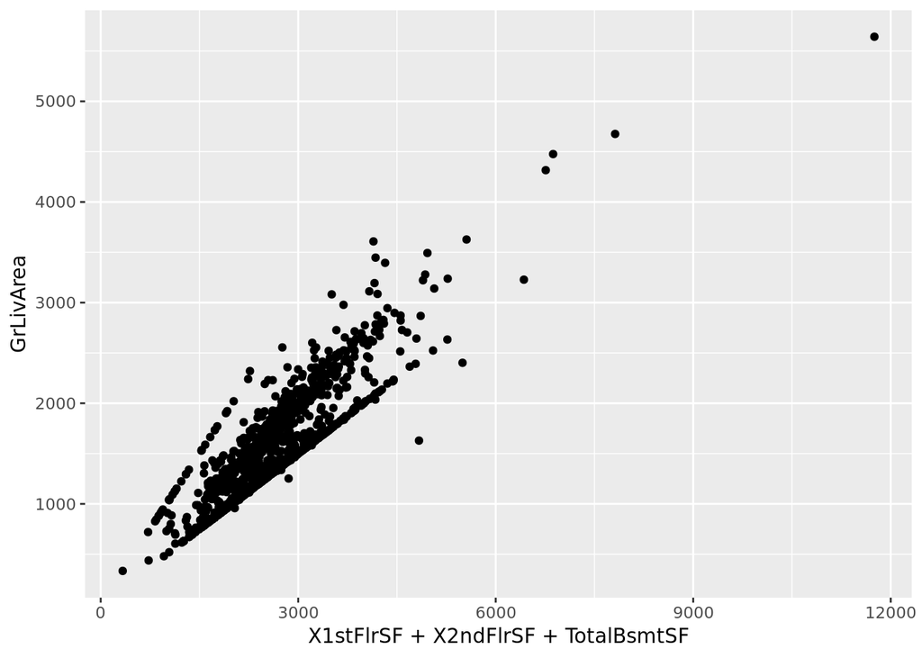

```r
ggplot(House_Train) + geom_point(aes(x = `X1stFlrSF` + `X2ndFlrSF` + TotalBsmtSF, y = GrLivArea))
```

This is where I begin to deviate slightly from the data cleaning done in class.

I will add total SF together and drop the other variables

```r
House_Train<-House_Train %>%mutate(TotalSF=X1stFlrSF+X2ndFlrSF+TotalBsmtSF+ GarageArea)
House_Train <- House_Train %>%
  select(-c(`X1stFlrSF`, `X2ndFlrSF`, LowQualFinSF, TotalBsmtSF, GrLivArea, GarageArea))
```

```r
numeric_vars <- which(sapply(House_Train, is.numeric))
numeric_vars
```

```
##   LotFrontage       LotArea     YearBuilt  YearRemodAdd    MasVnrArea
##             3             4            19            20            26
##      FullBath      HalfBath  BedroomAbvGr  KitchenAbvGr  TotRmsAbvGrd
##            44            45            46            47            49
##    Fireplaces    WoodDeckSF   OpenPorchSF EnclosedPorch    X3SsnPorch
##            51            60            61            62            63
##   ScreenPorch      PoolArea       MiscVal        MoSold        YrSold
##            64            65            69            70            71
##     SalePrice       TotalSF
##            74            75
```

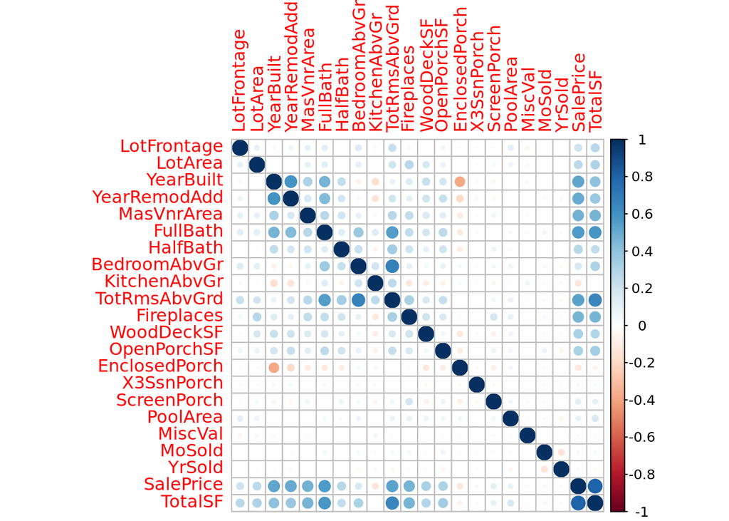

```r
corrplot(cor(House_Train[, numeric_vars], use="pairwise.complete.obs"))
```

```r
cor_matrix<-cor(House_Train[, numeric_vars], use="pairwise.complete.obs")
highcor_thresh <- 0.5
cor_saleprice <- cor_matrix[, 'SalePrice']
cor_saleprice[cor_saleprice > highcor_thresh]
```

```
##    YearBuilt YearRemodAdd     FullBath TotRmsAbvGrd    SalePrice
##    0.5228973    0.5071010    0.5606638    0.5337232    1.0000000
##      TotalSF
##    0.8095613
```

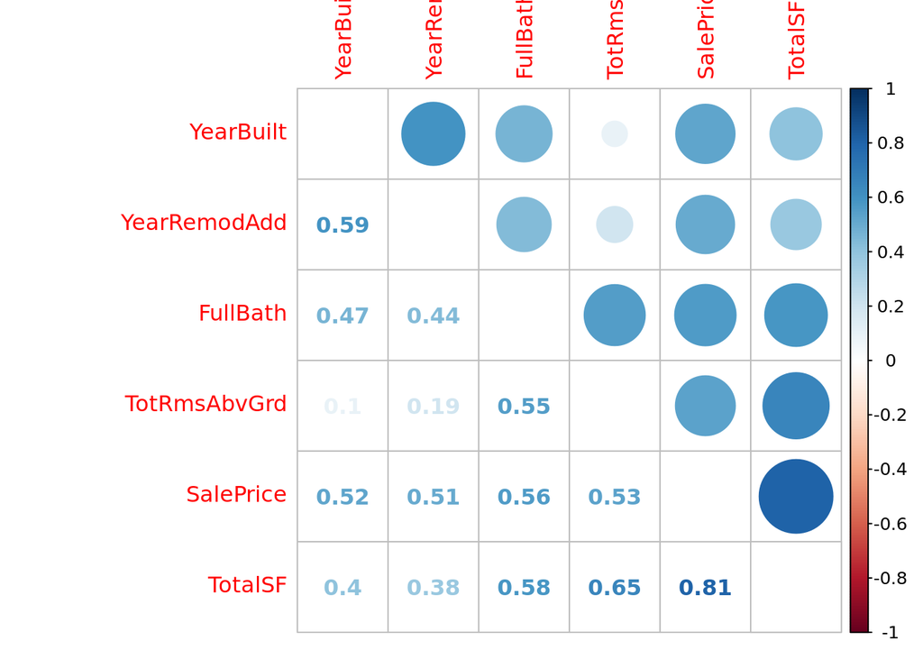

```r
highcor_vars <- names(cor_saleprice[cor_saleprice > highcor_thresh])
corrplot.mixed(cor(House_Train[, highcor_vars], use="pairwise.complete.obs"),
               tl.pos = "lt")
```

Theoretically you would want to repeat this for negative correlations:

```r
umeric_vars <- which(sapply(House_Train, is.numeric))
numeric_vars
```

```
##   LotFrontage       LotArea     YearBuilt  YearRemodAdd    MasVnrArea
##             3             4            19            20            26
##      FullBath      HalfBath  BedroomAbvGr  KitchenAbvGr  TotRmsAbvGrd
##            44            45            46            47            49
##    Fireplaces    WoodDeckSF   OpenPorchSF EnclosedPorch    X3SsnPorch
##            51            60            61            62            63
##   ScreenPorch      PoolArea       MiscVal        MoSold        YrSold
##            64            65            69            70            71
##     SalePrice       TotalSF
##            74            75
```

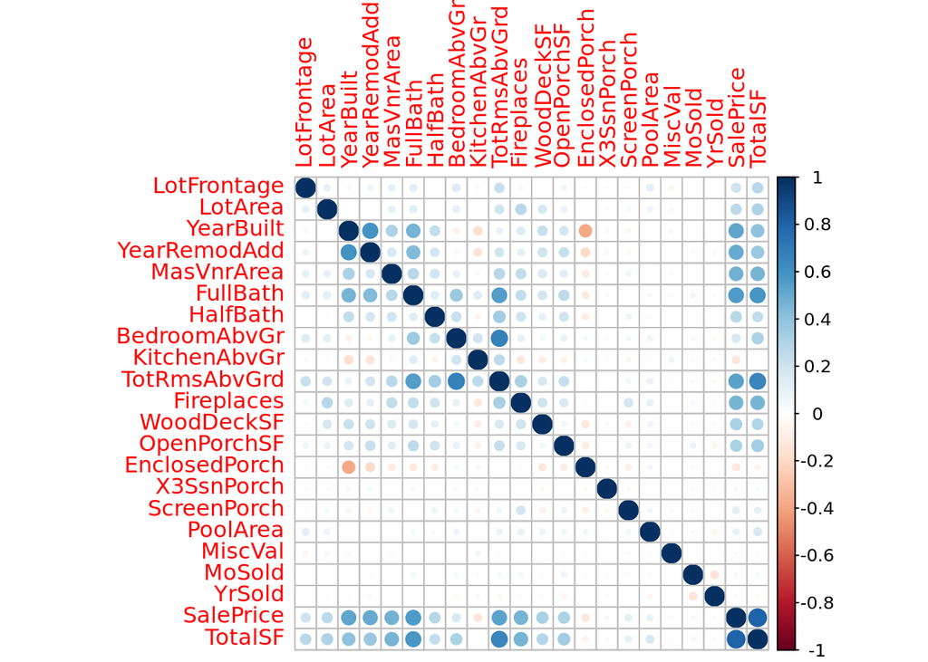

```r
corrplot(cor(House_Train[, numeric_vars], use="pairwise.complete.obs"))
```

```r
cor_matrix<-cor(House_Train[, numeric_vars], use="pairwise.complete.obs")
lowcor_thresh <- -0.5
cor_saleprice <- cor_matrix[, 'SalePrice']
cor_saleprice[cor_saleprice < lowcor_thresh]
```

```
## named numeric(0)
```

```r
lowcor_vars <- names(cor_saleprice[cor_saleprice < lowcor_thresh])
```

as you can see, we don’t have any in that range.

Another way to assess multicollinearity is through the variance inflation factor or VIF

A VIF of over 5 suggests multicolinearity and perhaps that variable should be removed from the model.

The variables above this mark include year remolded and year built, total square feet and total bath and total square feet and total rooms above ground.

```r
House_Train <- House_Train %>%
  select(-c(`FullBath`, TotRmsAbvGrd, YearRemodAdd))
```

```r
numeric_vars <- which(sapply(House_Train, is.numeric))
numeric_vars
```

```
##   LotFrontage       LotArea     YearBuilt    MasVnrArea      HalfBath
##             3             4            19            25            43
##  BedroomAbvGr  KitchenAbvGr    Fireplaces    WoodDeckSF   OpenPorchSF
##            44            45            48            57            58
## EnclosedPorch    X3SsnPorch   ScreenPorch      PoolArea       MiscVal
##            59            60            61            62            66
##        MoSold        YrSold     SalePrice       TotalSF
##            67            68            71            72
```

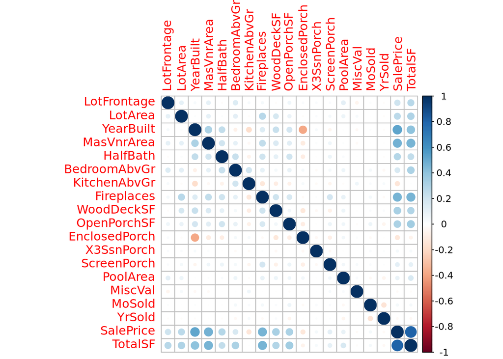

```r
corrplot(cor(House_Train[, numeric_vars], use="pairwise.complete.obs"))
```

```r
cor_matrix<-cor(House_Train[, numeric_vars], use="pairwise.complete.obs")
highcor_thresh <- 0.5
cor_saleprice <- cor_matrix[, 'SalePrice']
cor_saleprice[cor_saleprice > highcor_thresh]
```

```
## YearBuilt SalePrice   TotalSF
## 0.5228973 1.0000000 0.8095613
```

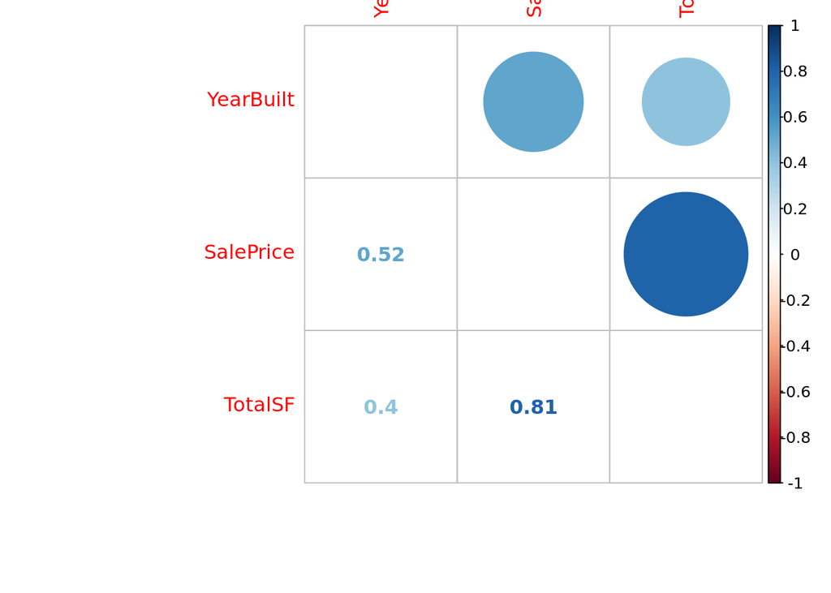

```r
highcor_vars <- names(cor_saleprice[cor_saleprice > highcor_thresh])
corrplot.mixed(cor(House_Train[, highcor_vars], use="pairwise.complete.obs"),
               tl.pos = "lt")
```

## Model Partitioning

I need to have a train and test set that I can use. I don’t have sale price for the data set provided by Kaggle, so I need to partition the train set.

```r
set.seed(47)
trainIndex <- caret::createDataPartition(House_Train$SalePrice, p = 0.8,
                                  list = FALSE,
                                  times = 1)

MYtrain <- House_Train[trainIndex, 1:ncol(House_Train)]
MYtest <- House_Train[-trainIndex, 1:ncol(House_Train)]
```

Now I’ve made a very small model with just the numeric variables, which I’ve modified to get rid of multicollinearity issues

```r
SmallModel <- lm(SalePrice ~YearBuilt+TotalSF, data=MYtrain)
summary(SmallModel)
```

```
##
## Call:
## lm(formula = SalePrice ~ YearBuilt + TotalSF, data = MYtrain)
##
## Residuals:
##     Min      1Q  Median      3Q     Max
## -649558  -19626   -4128   15905  287864
##
## Coefficients:
##               Estimate Std. Error t value Pr(>|t|)
## (Intercept) -1.243e+06  8.955e+04  -13.88   <2e-16 ***
## YearBuilt    6.298e+02  4.627e+01   13.61   <2e-16 ***
## TotalSF      5.981e+01  1.459e+00   40.99   <2e-16 ***
## ---
## Signif. codes:  0 '***' 0.001 '**' 0.01 '*' 0.05 '.' 0.1 ' ' 1
##
## Residual standard error: 43680 on 1166 degrees of freedom
## Multiple R-squared:  0.6996, Adjusted R-squared:  0.6991
## F-statistic:  1358 on 2 and 1166 DF,  p-value: < 2.2e-16
```

Our R squared value here is already 0.6996 suggesting that these 2 variables alone can explain about 70% of the variation in house price.

Here we create the Y- hat values for the test data.

```r
predsmall <- predict(SmallModel, newdata = MYtest)
```

Next we test it on the training data

```r
maeSmallModelfit <- MAE(y_pred = fitted.values(SmallModel), y_true = MYtrain$SalePrice)
maeSmallModelfit
```

```
## [1] 26779.47
```

and finally run it on the test data to see how it does.

```r
maeSmallModel <- MAE(y_pred = predsmall, y_true = MYtest$SalePrice)
maeSmallModel
```

```
## [1] 26520.14
```

That’s interesting. My test data has a lower error than the training data.

If the training data led to a small amount of error, while the test data had high MAE, that would intake over fitting.

I’ve obviously taken care of that. Perhaps now I have under fitting. The better models created in class had a lower MAE value of 18826, but also had a significantly larger amount of data prep.

```r
BigModel <- lm(SalePrice ~ ., data = House_Train)
summary(BigModel)
```

[output not shown]

[output cut: 2383 more lines]

```
## SaleTypeConLw                   NA         NA      NA       NA
## SaleTypeCWD                     NA         NA      NA       NA
## SaleTypeNew                     NA         NA      NA       NA
## SaleTypeOth                     NA         NA      NA       NA
## SaleTypeWD                      NA         NA      NA       NA
## SaleConditionAdjLand            NA         NA      NA       NA
## SaleConditionAlloca             NA         NA      NA       NA
## SaleConditionFamily             NA         NA      NA       NA
## SaleConditionNormal             NA         NA      NA       NA
## SaleConditionPartial            NA         NA      NA       NA
## TotalSF                         NA         NA      NA       NA
##
## Residual standard error: 5750 on 1 degrees of freedom
## Multiple R-squared:      1,  Adjusted R-squared:  0.9948
## F-statistic:   191 on 1458 and 1 DF,  p-value: 0.05767
```

```r
predBig <- predict(BigModel, newdata = MYtest)
maeBiglModelfit <- MAE(y_pred = fitted.values(BigModel), y_true = MYtrain$SalePrice)
maeBiglModelfit
```

```
## [1] 78763.68
```

```r
maeBigModel <- MAE(y_pred = predBig, y_true = MYtest$SalePrice)
maeBigModel
```

```
## [1] 9.879725
```

```r
House_Train$OverallQual= as.numeric(House_Train$OverallQual)

model3 <- lm(SalePrice ~YearBuilt+TotalSF+OverallQual, data=MYtrain)
summary(model3)
```

```
##
## Call:
## lm(formula = SalePrice ~ YearBuilt + TotalSF + OverallQual, data = MYtrain)
##
## Residuals:
##     Min      1Q  Median      3Q     Max
## -559984  -15886    -427   13168  250092
##
## Coefficients:
##                 Estimate Std. Error t value Pr(>|t|)
## (Intercept)   -5.920e+05  8.650e+04  -6.844 1.25e-11 ***
## YearBuilt      3.133e+02  4.278e+01   7.322 4.56e-13 ***
## TotalSF        3.777e+01  1.559e+00  24.220  < 2e-16 ***
## OverallQual2  -1.292e+04  3.589e+04  -0.360 0.718974
## OverallQual3  -1.514e+03  2.697e+04  -0.056 0.955235
## OverallQual4   5.602e+03  2.573e+04   0.218 0.827681
## OverallQual5   1.650e+04  2.560e+04   0.645 0.519243
## OverallQual6   2.803e+04  2.567e+04   1.092 0.275157
## OverallQual7   5.274e+04  2.585e+04   2.041 0.041521 *
## OverallQual8   8.761e+04  2.613e+04   3.352 0.000827 ***
## OverallQual9   1.663e+05  2.688e+04   6.186 8.54e-10 ***
## OverallQual10  1.855e+05  2.826e+04   6.562 7.98e-11 ***
## ---
## Signif. codes:  0 '***' 0.001 '**' 0.01 '*' 0.05 '.' 0.1 ' ' 1
##
## Residual standard error: 35890 on 1157 degrees of freedom
## Multiple R-squared:  0.7987, Adjusted R-squared:  0.7968
## F-statistic: 417.3 on 11 and 1157 DF,  p-value: < 2.2e-16
```

```r
pred3<- predict(model3, newdata = MYtest)
mae3Modelfit <- MAE(y_pred = fitted.values(model3), y_true = MYtrain$SalePrice)
mae3Modelfit
```

```
## [1] 21688.8
```

```r
mae3Model <- MAE(y_pred = pred3, y_true = MYtest$SalePrice)
mae3Model
```

```
## [1] 22882.5
```

This has lowered the MAE. It looks like we eliminated more variables than we would have.

```r
House_Train$OverallCond= as.numeric(House_Train$OverallQual)

model4 <- lm(SalePrice ~TotalSF+OverallQual+Neighborhood+KitchenQual, data=MYtrain)
summary(model4)
```

```
##
## Call:
## lm(formula = SalePrice ~ TotalSF + OverallQual + Neighborhood +
##     KitchenQual, data = MYtrain)
##
## Residuals:
##     Min      1Q  Median      3Q     Max
## -473385  -14024    -106   12819  220061
##
## Coefficients:
##                       Estimate Std. Error t value Pr(>|t|)
## (Intercept)          70810.921  26696.192   2.652  0.00810 **
## TotalSF                 31.536      1.546  20.397  < 2e-16 ***
## OverallQual2         -7329.034  33175.933  -0.221  0.82520
## OverallQual3          4002.616  25232.264   0.159  0.87399
## OverallQual4         11458.617  24176.817   0.474  0.63563
## OverallQual5         17877.759  24162.337   0.740  0.45951
## OverallQual6         27730.252  24209.885   1.145  0.25228
## OverallQual7         45328.470  24417.892   1.856  0.06366 .
## OverallQual8         68804.751  24721.042   2.783  0.00547 **
## OverallQual9        130054.406  25793.558   5.042 5.36e-07 ***
## OverallQual10       156718.468  26960.646   5.813 7.98e-09 ***
## NeighborhoodBlueste  -6325.377  34348.319  -0.184  0.85393
## NeighborhoodBrDale  -16564.003  13358.159  -1.240  0.21524
## NeighborhoodBrkSide   -957.285  11020.464  -0.087  0.93079
## NeighborhoodClearCr  34942.643  11979.556   2.917  0.00361 **
## NeighborhoodCollgCr  15084.260  10036.940   1.503  0.13315
## NeighborhoodCrawfor  36945.301  10930.661   3.380  0.00075 ***
## NeighborhoodEdwards  -9478.068  10631.759  -0.891  0.37286
## NeighborhoodGilbert  22409.710  10449.931   2.144  0.03221 *
## NeighborhoodIDOTRR  -19268.682  11746.081  -1.640  0.10119
## NeighborhoodMeadowV -11981.136  13461.764  -0.890  0.37365
## NeighborhoodMitchel   7709.954  11300.720   0.682  0.49522
## NeighborhoodNAmes     2247.797  10238.114   0.220  0.82626
## NeighborhoodNoRidge  67985.456  11422.564   5.952 3.53e-09 ***
## NeighborhoodNPkVill  -1111.969  16755.013  -0.066  0.94710
## NeighborhoodNridgHt  34415.783  10925.689   3.150  0.00168 **
## NeighborhoodNWAmes   10109.493  10669.948   0.947  0.34360
## NeighborhoodOldTown -19689.124  10484.520  -1.878  0.06065 .
## NeighborhoodSawyer    2586.311  10880.270   0.238  0.81215
## NeighborhoodSawyerW  15199.894  10772.929   1.411  0.15854
## NeighborhoodSomerst  17811.243  10387.615   1.715  0.08668 .
## NeighborhoodStoneBr  53720.913  12972.990   4.141 3.72e-05 ***
## NeighborhoodSWISU    -3240.021  12036.515  -0.269  0.78784
## NeighborhoodTimber   24436.571  11256.754   2.171  0.03015 *
## NeighborhoodVeenker  37101.359  14672.909   2.529  0.01159 *
## KitchenQualFa       -45733.919   8242.690  -5.548 3.59e-08 ***
## KitchenQualGd       -27574.272   5395.059  -5.111 3.76e-07 ***
## KitchenQualTA       -39235.682   5744.766  -6.830 1.39e-11 ***
## ---
## Signif. codes:  0 '***' 0.001 '**' 0.01 '*' 0.05 '.' 0.1 ' ' 1
##
## Residual standard error: 32810 on 1131 degrees of freedom
## Multiple R-squared:  0.8355, Adjusted R-squared:  0.8302
## F-statistic: 155.3 on 37 and 1131 DF,  p-value: < 2.2e-16
```

```r
pred4<- predict(model4, newdata = MYtest)
mae4Modelfit <- MAE(y_pred = fitted.values(model4), y_true = MYtrain$SalePrice)
mae4Modelfit
```

```
## [1] 19907.39
```

```r
mae4Model <- MAE(y_pred = pred4, y_true = MYtest$SalePrice)
mae4Model
```

```
## [1] 21356.79
```

My error values are decreasing. The stars next to each category show which variables are significant.

## GitHub Link

https://github.com/afedewa/MIS4470Final.git

## Conclusions

I hope I was able to showcase some of the methods we learned in this course while applying them to a new situation. This model is not ready to compete in the kaggle competition, where the current front runner has a logarithmic least squared error of only ~0.10, but I now know I can enter these competitions as a way to continue to build my knowledge of R and python.